# Seeing the Forest as well as the Trees: Creating a Tutorial to Compare Data Collected From Air and Space

by Hannah Rieder, Randi Neff and Bridget Hass

August, 2025

## Project Description

In this project, we used two data sources at different resolutions to confirm the assertion that while detailed data is valuable, time is also important. Data at larger scales can reduce computation time and potentially provide similar information. The datasets we used include:

- An aerial survey from The National Ecological Observatory Network (NEON) and
- Data from the International Space Station Earth Surface Mineral Dust Source Investigation (EMIT) sensor

We wanted to understand when the coarser resolution EMIT data might suffice, and when the higher resolution NEON data would be needed, in the context of monitoring forest health. Open data is a shared value for our project team and our project advisor was interested in creating a reproducible tutorial to showcase an ecological application involving scaling EMIT and NEON remote sensing datasets. Currently, an applied tutorial comparing NEON and EMIT reflectance data doesn’t exist. Our tutorial shows how to calculate canopy water content (CWC) as a measure of forest health and considers the tradeoffs between data resolution and efficiency / coverage. NEON data are higher resolution but EMIT data provide larger spatial coverage and can also be processed much faster.

## Project Scope

We created a tutorial to answer two questions:

- Does low resolution data from space agree with high resolution data from an aerial survey?
- Can maps from space effectively diagnose forest health?

The combination of detailed ground observations and broad-scale satellite data can significantly improve the accuracy and predictive power of ecological and Earth system models. Both EMIT and NEON provide hyperspectral reflectance data which were used as inputs to calculate CWC

## Project Location

The first step of our project was to choose an area of interest. We wanted to compare burned and unburned areas to apply our project to a disturbance event. The NEON Soaproot Saddle (SOAP) site, which was burned by the Creek wildfire in 2020, was an ideal site for this comparison. Figure 1 shows the overlap in data collection by EMIT and NEON, while figures 2 and 3 show greater detail of the area evaluated.

[figure not shown]

[figure not shown]

Since hyperspectral instruments are passive sensors, we needed cloud-free data. We were only able to find cloud-free EMIT data in 2023 and cloud-free NEON data in 2024 so we evaluated data collected in different years, but both datasets were acquired during the summer months. In figure 3, the orange and green squares show the burned and unburned areas from the Creek fire that were the focus of our tutorial.

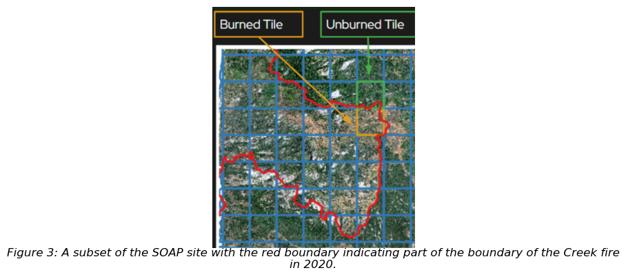

## Project Methods

We cropped the downloaded reflectance data sets to the burned and unburned ‘tiles’, and calculated canopy water content using a functions provided in an existing tutorial from the EMIT VITALS GitHub repository To compare the CWC calculated from the two datasets, we resampled the NEON data to match the resolution of the EMIT data and then plotted the difference in CWCvalues. Figure 4 illustrates this process.

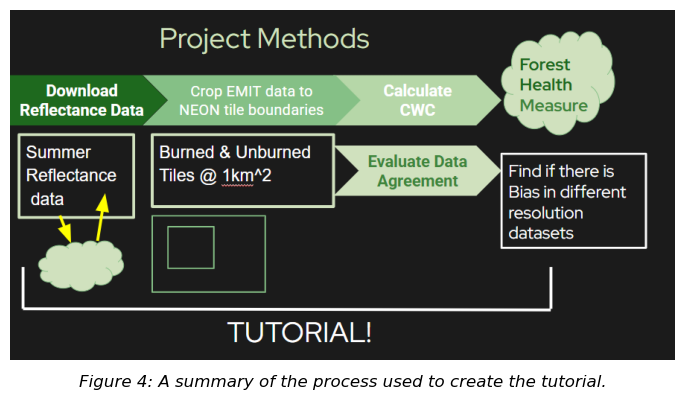

## Project Results

Looking at the calculations of CWC in figure 5, we can clearly see that the EMIT CWC plot has fewer pixels and less detail than the NEON-derived CWC plot. Despite the difference in resolution, we can answer the question, “Does low resolution data from space agree with high resolution data from an aerial survey?”, as “yes”. We can see that areas of high CWC in the EMIT plots are mirrored by areas of high CWC in the NEON plots.

[figure not shown]

From these summary figures we can visually see that there is alignment in CWC values in the EMIT and NEON datasets. Differences between the two could be due to temporal differences in the date of collection, resolution differences, or other factors such as different atmospheric corrections applied to the two datasets.

For our second project question, “Can maps from space effectively diagnose forest health?”, our answer is “maybe”. EMIT data can summarize the forest condition, but will lack the nuances that the NEON data provide.

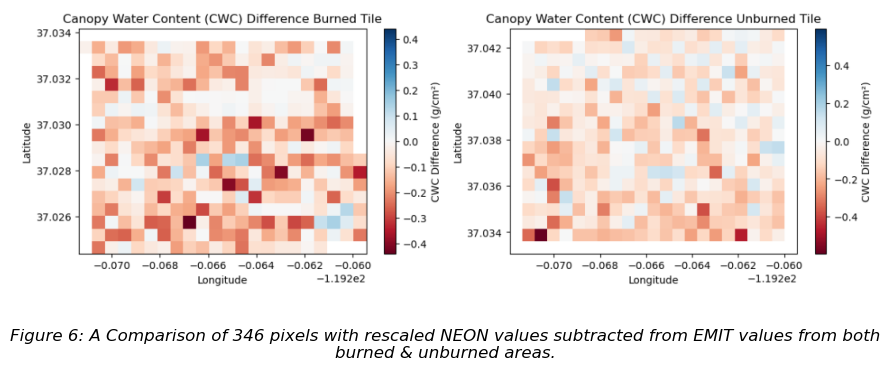

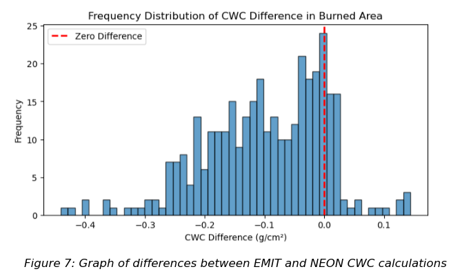

Looking at figures 6 and 7, it is clear that the EMIT calculations of CWC are consistently lower than those derived from NEON data. The mean difference in CWC is -0.09 g/cm² OR -0.08 g/cm² depending on the tiles evaluated. When using the two together, a correction factor would need to be applied.

## Project Extensions

If we extended this project, we could explore other applications such as classifying forest health based upon CWC and seeing if there are differences in CWC depending upon the time of year (e.g. seasonal variation). NEON samples during summer months (near peak phenological greenness) while EMIT collects images throughout the year, so EMIT may provide more opportunities to assess seasonal patterns. Finally, we could model CWC measurements to extrapolate forest health from NEON sites to a continental or even global scale.

## Acknowledgements

Thanks to Bridget Hass, our NEON mentor.

https://www.neonscience.org/resources/learning-hub/tutorials/discrete-lidar-wildfires

https://nasa.github.io/VITALS/python/03_EMIT_CWC_from_Reflectance.html